# Analyse-Report

### **ZÜRICH TRAM FLOW: 01/2023 – 12/2025**

**Fokus** Wo · Wann · Warum — Verspätungen im Zürcher Tramnetz  
**Ziel** Strukturelle Muster sichtbar machen · Basis für operative Empfehlungen

**Daten-Quelle**

- IST-Daten von opentransportdata.swiss
- GTFS- und Meteo-Datan von data.stadt-zuerich.ch

**Daten-Umfang**

- Exploration: ~94,4 Mio. Zeilen · 16 Tramlinien · 26 Spalten
- Analyse: ~85,4 Mio. Zeilen · 16 Tramlinien · 42 Spalten

**Herausforderungen**

- Datenmenge (3 Jahre)
- Datenqualität (Betriebsbedingt)

**Überblick**

- Erkenntnisse
  - Netzstruktur
  - Geografie
  - Temporalität
  - Meteorologie
  - Ereignisse
  - Infrasturkur
- Empfehlungen

## Kernthese

> "Die Verspätungen im Zürcher Tramnetz sind vorhersagbar, sie sind systematisch —  
> weil sie im Fahrplan-Design verankert sind, nicht im Betrieb."

Drei strukturelle Befunde, die zusammen mehr sagen als jeder einzeln:

- **Fahrplan als Treiber:** 71.5% aller Halte akkumulieren Delay · 71.3% haben keine Pufferzeit (dwell_time = 0 s) — das Problem ist eingebaut, nicht operativ
- **Vorhersagbare Kaskade:** Pearson r ≥ 0.85 netzweit — Delay überträgt sich fast vollständig von Halt zu Halt · Ein Modell (LightGBM, MAE 45.7 s) kann das reproduzieren
- **Konsequenz:** Was vorhersagbar ist, ist steuerbar · Die Lösung liegt im Fahrplan-Design: Puffer an den richtigen Stellen — nicht im Netzausbau

```python
import plotly.io as pio
pio.renderers.default = "notebook_connected"  # Plotly: CDN-Link im Output → HTML-Export funktioniert

from zh_tram_flow.notebook import *
import zh_tram_flow.analytics as an
from zh_tram_flow.visualization.insights import (
    plot_monthly_delay_by_line,
    plot_otp_by_line,
    plot_otp_delta_distribution,
    plot_dwell_analysis,
    plot_dwell_throughput,
    plot_dwell_vs_delay,
    plot_district_maps,
    plot_district_delay_map,
    plot_district_otp_map,
    plot_infra_maps,
    plot_delay_delta_timeline,
    plot_arrival_vs_departure_timeline,
    plot_lever_comparison,
    plot_dwell_scatter,
    plot_dwell_line_scatter,
)

TRAIN, TEST, lf, lf_all, lf_delay, lf_clean = setup_analysis("04_insights")
```

```
✓  wgnd theme activated (matplotlib · seaborn)
```

```
2026-06-11 15:56:40  INFO      project  04_insights started
```

## Hebel-Vergleich: Fahrplan-Struktur vs. Externe Faktoren

Wie schwer wiegt die strukturelle Fahrplan-Schwäche im Vergleich zu situativen Einflussfaktoren?

- **Struktureller Hebel** — `mean(delay_delta) × avg_stops_per_trip`: kumulierter Verspätungsaufbau über eine Ø Fahrt — tritt **jeden Tag**, auf jeder Linie, unabhängig vom Kontext auf
- **Externe Faktoren** — gemessener Δ Arrival Delay pro Halt vs. Normalbedingung: situativ, nur wenn Bedingung eintrifft (Schnee, Event, Tageszeit)

#### Befund

Der Fahrplan selbst ist der grösste Hebel — grösser als Schnee, grösser als Grossereignisse, grösser als der Abend-Peak. Und anders als Wetter oder Events ist er steuerbar.

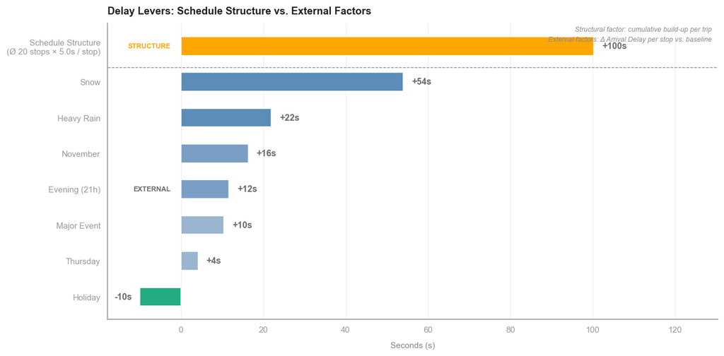

```python
plot_lever_comparison(lf_clean)
```

## Netzstruktur

- Stabile Verspätungswerte trotz großer Einschnitte
- On-Time-Performance (OTP) unter Zielvorgaben
- Akkumulierte Verspätungen durch zu wenig Puffer

### Wiederkehrende Einschnitte

**Fahrplanwechsel Dez 2023**  
Zu dem Zeitpunkt grösster Netzumbau der VBZ-Geschichte: 10 von 17 Linien umgebaut, L9/L11/L13 mit neuen Streckenführungen und Haltestellen.

**Groß-Baustelle Ende im Jun 2024**  
L12 Streckensperrung mit Ersatzverkehr (Jan 2023–Jun 2024). Ausfallrate 20× über Netzschnitt während der Bauphase.

**Fahrplanwechsel Dez 2024**  
Stabiler Übergang, geringer Eingriff (L5: +5 Halte).

**Fahrplanwechsel Dez 2025**  
Grösster Fahrplanwechsel der VBZ-Geschichte: 7 von 18 Linien signifikant umgebaut. Neu: „Tramnetz Süd" mit L50/L51 als provisorische Baustellen-Linien für die Bahnhofquai/HB-Sanierung (bis Dez 2026).

#### Befund

**Kein erkennbarer Effekt auf das Verspätungsverhalten**

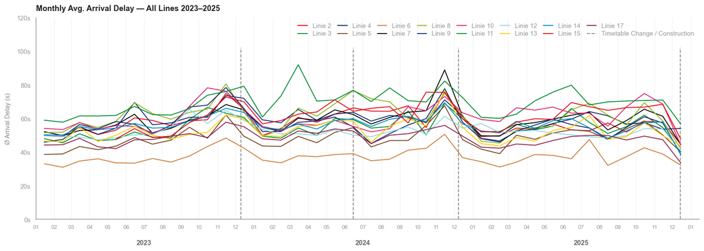

```python
plot_monthly_delay_by_line(lf_clean)
```

### On-Time-Performance

OTP-Definitio der VBZ:  
**"Anteil aller Ankünfte innerhalb von ±120 Sekunden (±2 Min.) des Fahrplans."**

**OTP Werte netzweit**

- Über alle Tram-Linien hinweg wird eine OTP von 87% erreicht.
- Bester Wert liegt bei 93,4% der Linie 6
- Schlechtester Wert liegt bei 81,6% der Linie 11

#### Befund

- Das Netz liegt mit 87% rund 8 Prozentpunkte unter dem VBZ-Ziel von 95%.
- Die Spanne reicht von 81.6% (L11) bis 93.4% (L6) — alle Linien verfehlen das Ziel.

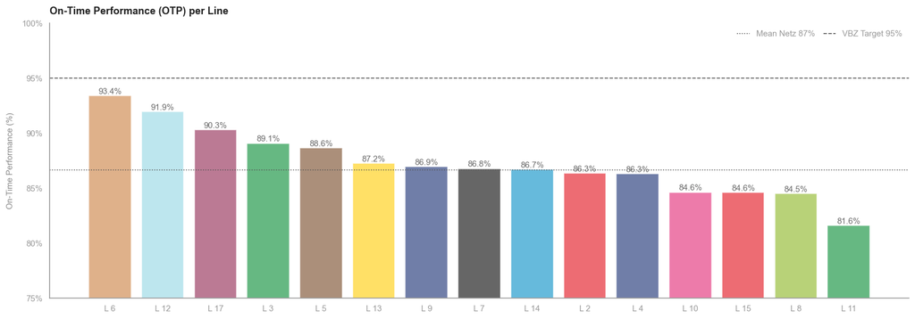

```python
plot_otp_by_line(lf_clean)
```

### Akkumulierende Verspätungen

**71.5% aller Halte** — Verspätung wächst Stop zu Stop

- 27.2% bauen Verspätung ab · 1.3% neutral
- 71.3% aller Halte haben keine Verweilzeit (dwell_time = 0s) und dadurch kein Puffer zum Nachholen

#### Befund

- Verspätungen entstehen nicht punktuell — sie wachsen systematisch über den gesamten Trip
- Fehlende Pufferzeit ist die Ursache: ohne dwell_time kann das Tram verlorene Zeit nicht aufholen
- Das ist ein Fahrplan-Problem, kein Kapazitätsproblem — die Lösung liegt im Design, nicht im Ausbau

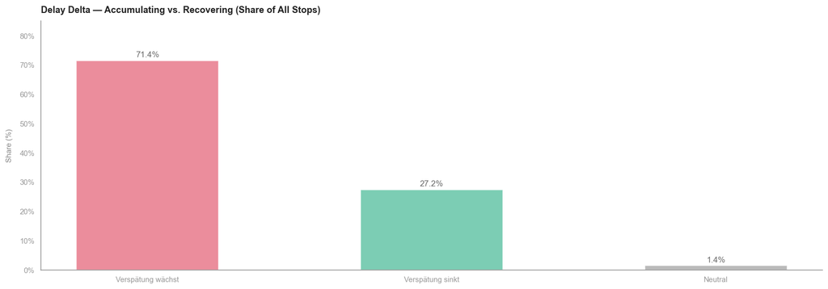

```python
plot_otp_delta_distribution(lf_clean)
```

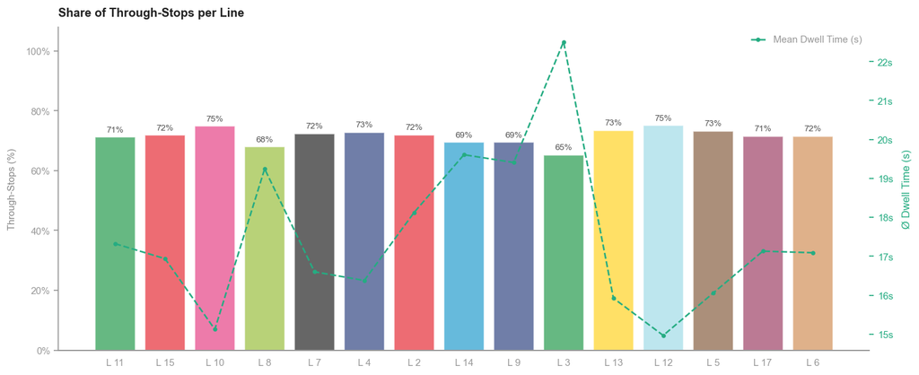

```python
plot_dwell_throughput(lf_clean)
```

#### Verweilzeiten pro Linie und Verspätungen

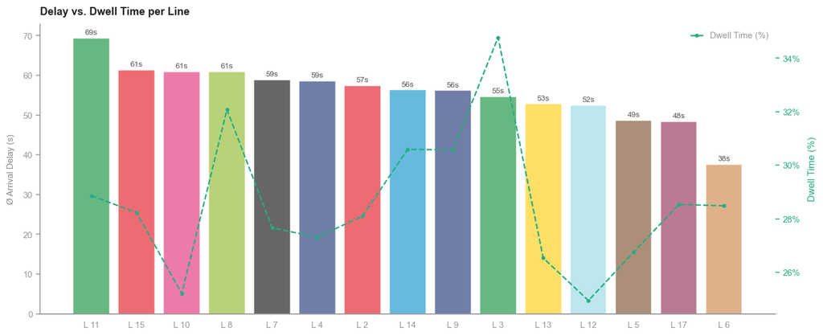

```python
plot_dwell_vs_delay(lf_clean)
```

### Strukturelle Stop-Typen: Akkumulations-Fallen & Recovery-Anker

Nicht alle Stops sind gleich — die Daten zeigen zwei klar trennbare Typen:

- **Akkumulations-Fallen** — dw0 ≥ 90%, hoher delay_delta: kein Puffer, jede Sekunde Verspätung die ankommt wird weitergegeben und verschlimmert. Bsp: Enzenbühl (94.6%, +9.5s/Halt), Mattenhof (95.5%, +11.9s/Halt), Messe/Hallenstadion (98.4%, +19.7s/Halt)
- **Recovery-Anker** — dw0 ≤ 50%, negativer delay_delta: echter geplanter Puffer, Trams bauen hier aktiv Verspätung ab. Bsp: Seebacherplatz (42.7%, −17.2s/Halt), Oerlikon (44.3%, −7.8s/Halt)

**Kernbefund:** Recovery-Anker kommen trotz Abbau mit 80–100s an — weil der Vorlauf so gross ist, dass selbst 34s Puffer nicht ausreicht. Das Netz versucht sich zu reparieren. Es scheitert am systematischen Vorlauf.

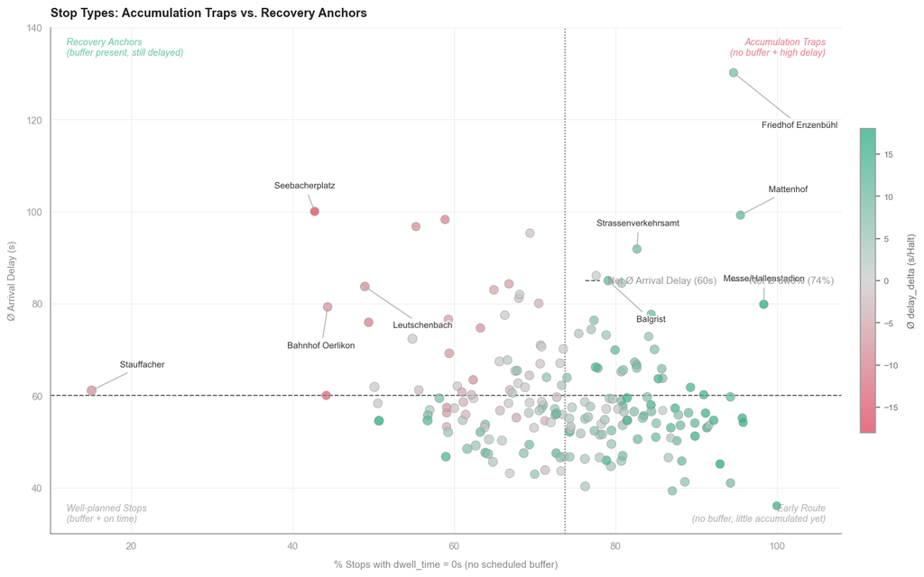

```python
plot_dwell_scatter(lf_clean)
```

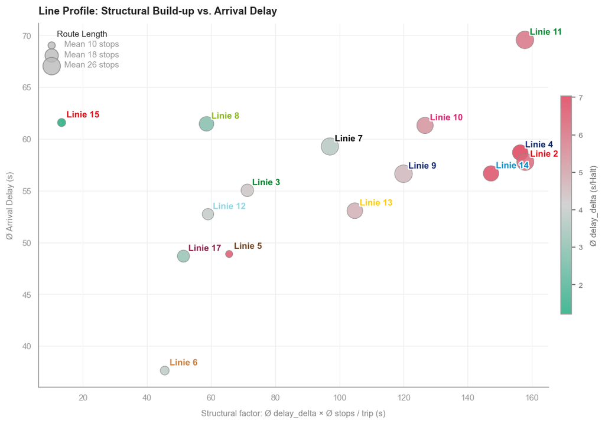

```python
plot_dwell_line_scatter(lf_clean)
```

## Geografie

### Haltestellen Delay-Hotspots

**Periphere Aussenkorridore** — nicht zentrale Knotenpunkte

**Strukturell schwächste Zonen**

#### Befund

- Hotspots liegen am Stadtrand — viel befahrene Innenstadtknoten performen besser als periphere Endpunkte
- Paradeplatz und Central (je 14–15 Linien) bestätigen: Frequenz allein ist kein Verspätungstreiber

```python
an.plot_stop_delay_map(lf_clean)
```

[interactive chart not shown]

### Das Muster entlang der Strecke: L11 vs. L6

Die Hotspot-Karte zeigt **wo** die Verspätung am höchsten ist — aber nicht **warum sie dort sitzt**.

Ein direkter Vergleich der schlechtesten und besten Linie macht das Muster sichtbar:

- **L11** (Rehalp–Auzelg · 30.2 km · OTP 81.6% · ⌀ 71 s) — Bubbles wachsen konsequent von der Mitte zur Peripherie: Verspätung akkumuliert entlang der Strecke und gipfelt an den Endhalten
- **L6** (HB–Zoo · OTP 93.4% · ⌀ 38 s) — Bubbles bleiben über die gesamte Strecke klein: eingebauter Puffer bricht die Kaskade

#### Befund

Hotspots sind **nicht** das Ergebnis schlechter Infrastruktur an diesen Punkten — sie sind das **Endprodukt einer Kettenreaktion**, die an der ersten Station beginnt. Der Unterschied zwischen L11 und L6 ist keine Frage des Glücks, sondern des Fahrplan-Designs.

```python
an.plot_line_delay_profile_map(lf_clean, lines=["11", "6"], cfg=cfg)
```

[interactive chart not shown]

### Mechanismus: Kein Puffer — keine Erholung

Warum kann L11 die angesammelte Verspätung nicht abbauen?

Die Dwell-Map zeigt die kritische Variable:

- **Farbe** — Ø Arrival Delay (Grün = pünktlich · Rot = verspätet)
- **Bubble-Grösse** — Anteil der Abfahrten **ohne** Pufferzeit (dwell_time = 0 s)

**Smoking Gun:** Die rötesten Bubbles sind gleichzeitig die grössten — die Haltestellen mit den schlimmsten Verspätungen haben den wenigsten Puffer. Kein Spielraum zum Aufholen. Die Verspätung, die ein Tram mitbringt, gibt es komplett weiter — und legt noch etwas drauf.

#### Befund

Das ist kein operatives Problem, das ein Fahrer lösen kann. Es ist ein **Fahrplan-Problem**: fehlende dwell_time ist eingebaut. Wer das beheben will, muss das Fahrplan-Design ändern — nicht den Betrieb.

```python
an.plot_stop_dwell_map(lf_clean, line_name="11")
```

[interactive chart not shown]

### Beweiskette: Kaskadeneffekt netzweit

Ist L11 ein Einzelfall — oder ist das ein systemisches Muster?

Der **Kaskadenkoeffizient** misst, wie stark sich die Verspätung eines Halts auf den nächsten überträgt (Pearson r):

- r → 1.0 = Delay kaskadiert vollständig — das Tram trägt jede Sekunde Verspätung einfach weiter
- r → 0.0 = Das Netz erholt sich — Verspätungen sind zufällig, kein Durchreichen

#### Befund

Die vier Schritte der Beweiskette sind damit geschlossen:

1. **Anomalie** — Hotspots liegen systematisch an peripheren Endhalten
2. **Gradient** — Delay wächst entlang der Strecke (L11 vs. L6 als Kontrast)
3. **Mechanismus** — Kein Puffer (dwell_time = 0 s) → keine Erholung möglich
4. **Beweis** — Pearson r ≥ 0.85 netzweit: systematische Kaskade, kein Zufall

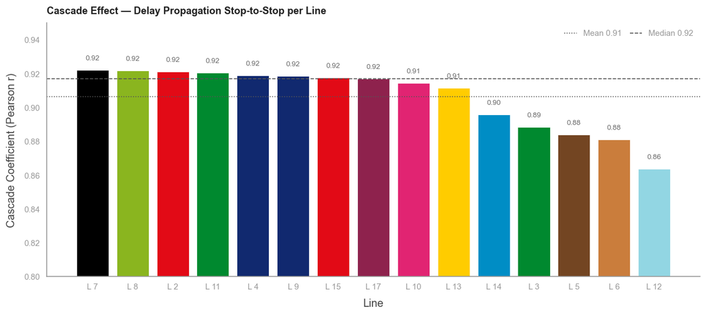

```python
an.plot_cascade_effect(lf_clean, ylim=(0.8, 0.95))
```

### Stadtkreise als Problemzonen

**Problemzone 1** — K11 · K12 · K8

**Problemzone 2** — K9 · K7 · Aussenbezirk

**Beste Kreise** — K5 · K10 · K1

- K5: 49.9s · OTP 89% — bester Kreis netzweit
- K1 (Paradeplatz / Innenstadt): 51.3s — bester Innenstadtknoten mit höchster Haltestellendichte (18.4 Mio. Beobachtungen)

#### Befund

- Zwei klar abgrenzbare Problemzonen — kein gleichmässiges Gefälle über das Netz
- Zentrale Knotenpunkte (K1: 51.3s) performen besser als periphere Aussenkorridore (K11: 68.3s) — Dichte ist kein Problem, Lage ist ein Problem
- OTP-Spanne zwischen bestem (K5: 89%) und schlechtestem Kreis (K11: 83%): 6 Prozentpunkte

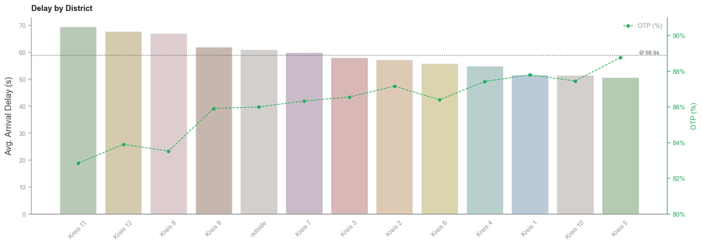

```python
an.plot_district_combined(lf_clean, ylim_otp=(80, 91))
```

## Temporalität

### Zeitliche Muster

**Abend-Peak** — 21h · 67.9s

**Wochentag**

- Schlechtester Tag: Donnerstag · 60.4s · P95 = 194s
- Bester Tag: Sonntag · 48.4s · Montag · 52.3s — Homeoffice-Effekt sichtbar

> **P95** — 95. Perzentil der Ankunftsverspätung: 95% aller Halte liegen *unter* diesem Wert, nur die schlechtesten 5% darüber. Zeigt Extremverspätungen, nicht den Alltag.

#### Befund

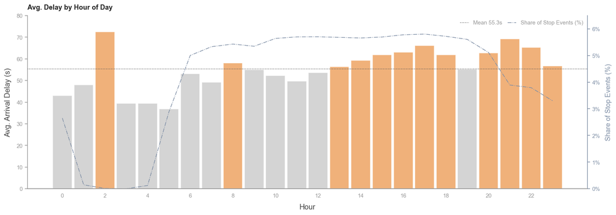

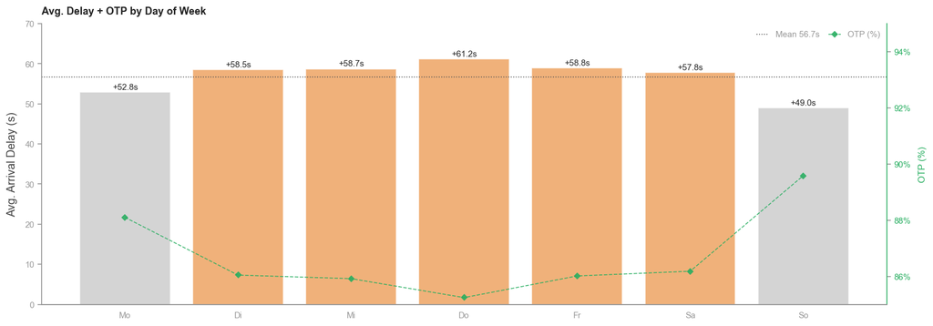

```python
an.plot_hour_of_day(lf_clean, cfg, ylim=(0,80), ylim_volume=(0, 6.5))

an.plot_day_of_week(lf_clean, cfg, ylim=(0, 70), ylim_otp=(85, 95))
```

## Meteorologie

- Wetter ereignisse sind deutlich nachweisbar
- Regen, Starkregen und Schnee wirken sich aufsteigend aus
- Regen/Starkregen ist eher ein Problematik des Zentrums, K5
- Schnee hat ehr Einfluss auf die äusseren Stadtkreise, K10

### Wetter Ereignisse

**Stärkster Einzelfaktor** — Schnee · +54s · OTP −10.9pp

**Geografische Trennung**

- Schnee → Höhenlagen: K10 · K4 · K12
- Starkregen → Flusstäler: K5 (Escher Wyss / Toni-Areal)

**Linien-Paradox**

- L17: Schnee +7.7s · Regen +41.2s — reagiert umgekehrt zur Netztendenz
- L9: Schnee +75.9s · Regen +10.0s — extremste Schnee-Betroffenheit im Netz

#### Befund

- Schnee ist der einzige Wetterfaktor mit zweistelligem OTP-Einbruch (−10.9pp)
- Wetter trifft nicht alle Linien gleich — geografische Lage der Strecke entscheidet über Exposition
- Regen allein ist kein kritischer Faktor — erst Starkregen in Flusstälern zeigt nennenswerten Effekt

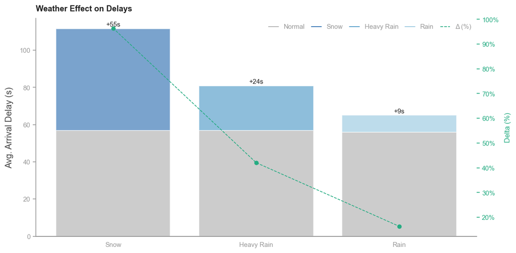

```python
an.plot_weather_overview(lf_clean)
```

```python
an.plot_weather_stop_map_combined(lf_clean)
```

[interactive chart not shown]

### Jahreszeit

**Beste Jahreszeit** — Winter · 51.7s · OTP 88.9%

- Herbst: 61.2s — schlechteste Jahreszeit · Sommer: 56.4s · Frühling: 55.6s
- Weniger MIV im Winter → weniger Kreuzungskonflikte — übertrifft den Schnee-Effekt

#### Befund

- Winter ist trotz Schnee die beste Jahreszeit — reduzierter Kfz-Verkehr überwiegt den Schnee-Malus
- Saisonspanne von 9.5s (Winter → Herbst) ist strukturell stabil über alle drei Messjahre
- Herbst kombiniert volles Verkehrsaufkommen mit wechselhaftem Wetter — belastendste Jahreszeit

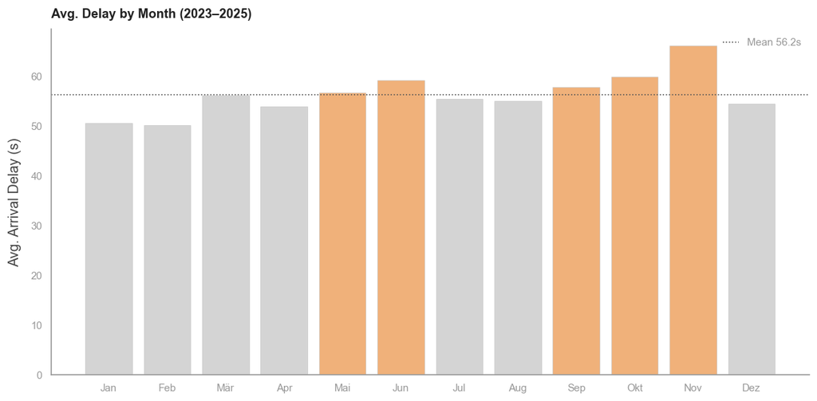

```python
an.plot_month_seasonality(lf_delay, cfg, panel="left")
```

## Großereignisse

- Besonders die Großereignisse fallen ins Gewicht, ab 20k
- Fachmessen und Kongresse sind kritischer als Konzerte
- Events wirken deutlich eher am abends

### Feiertage & Events

**Feiertage** — Bester Tag-Typ · 46.3s · OTP 90.6%

- −9.9s gegenüber einem normalen Werktag — reduzierter MIV als Haupttreiber
- Grosse Events: +10.5s — fast ausschliesslich abends 18–22h
- Tagsüber: Event-Tage ≈ Normaltage — kein messbarer Effekt vor 18h

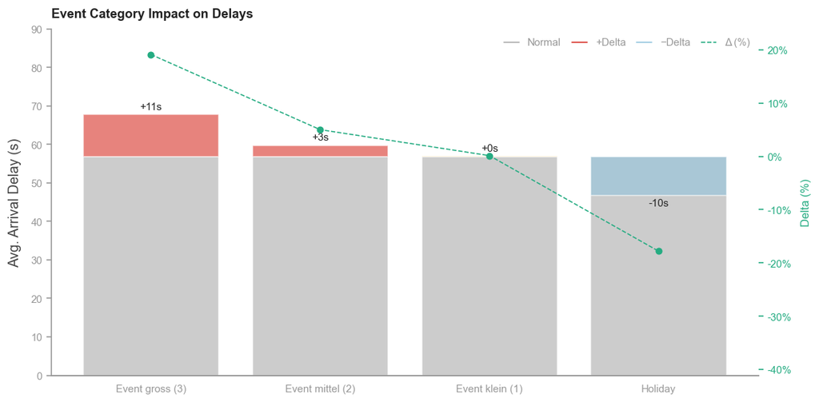

```python
an.plot_events_overview(lf_clean)
```

**Schlechteste Kategorie** — Fachmessen · 66.0s · OTP 84%

- Schlechtester Tag: Berufsmesse Zürich 21.11.2024 · 192.5s · OTP 54.5%
- Taylor Swift: 75.4s — Fachmessen schlagen Popkonzerte deutlich

#### Befund

- Feiertage entlasten das Netz stärker als jeder andere Faktor — 46.3s unterschreitet sogar den besten Kreisschnitt
- Fachmessen sind kritischer als Konzerte — andere Zielgruppe, andere Anreisezeit, weniger ÖPNV-Affinität
- Events wirken fast ausschliesslich abends — tageszeitliche Steuerung ist die wirksamste Gegenmassnahme

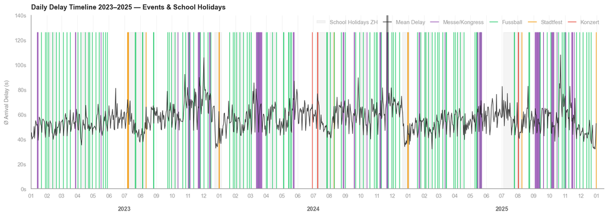

```python
plot_arrival_vs_departure_timeline(lf_clean)
```

### Netzausbau 2023

**Ausgebaut** — K3 · K8

- Sihlcity (K3): 56.0 s · Rehalp (K8): 63.8 s

**Nicht ausgebaut** — K11 · K12

- K11: 68.3 s · OTP 83% · K12: 66.3 s

#### Befund

Der Netzausbau Dez 2023 hat die Verspätungsstruktur **nicht verändert** — weder bei den ausgebauten Kreisen (K3/K8) noch bei den übrigen. Im monatlichen Timeline-Plot ist kein Knick sichtbar. Ausgebaute Linien wie L11 (+5.3 s nach Umbau) entwickeln sich identisch zu stabilen Referenzlinien (L15 +5.2 s).

Das ist kein Versagen — es ist ein Befund: **Infrastrukturausbau löst kein Fahrplan-Design-Problem.**

Wenn der grösste Netzumbau der VBZ-Geschichte keine messbare Wirkung auf das Verspätungsniveau hinterlässt, liegt die Ursache nicht in der Infrastruktur. Sie liegt in der Fahrplanstruktur: fehlende Pufferzeiten, die sich bei jeder Fahrt von Halt zu Halt aufschaukeln.

```python
plot_infra_maps(lf_delay, lf_clean)
```

[interactive chart not shown]

## Empfehlungen

**Strukturelle Muster** — stabil über 3 Jahre

[output not shown]